# Project Foundations for Data Science: FoodHub Data Analysis

## **Observations**

**Weekday vs. Weekend Delivery Times**:

- Weekdays: Delivery times are generally higher across most cuisine types compared to weekends.
- Weekends: Delivery times tend to be lower, indicating faster deliveries on weekends.

**Cuisine Types with Longest Delivery Times on Weekdays**:

**Cuisine Types with Shortest Delivery Times on Weekdays**:

- French: Average delivery time is approximately 27.20 minutes.
- Korean: Average delivery time is approximately 26.00 minutes.

**Cuisine Types with Longest Delivery Times on Weekends**:

**Cuisine Types with Shortest Delivery Times on Weekends**:

- Middle Eastern: Average delivery time is approximately 21.75 minutes.
- Korean: Average delivery time is approximately 20.00 minutes.

**Comparison Between Weekdays and Weekends**:

- Most cuisine types have a significant reduction in delivery times on weekends compared to weekdays.
- The difference in delivery times between weekdays and weekends is more pronounced for certain cuisines like American, Chinese, and Italian.

## Average Preparation Time by Day of the Week and Cuisine Type

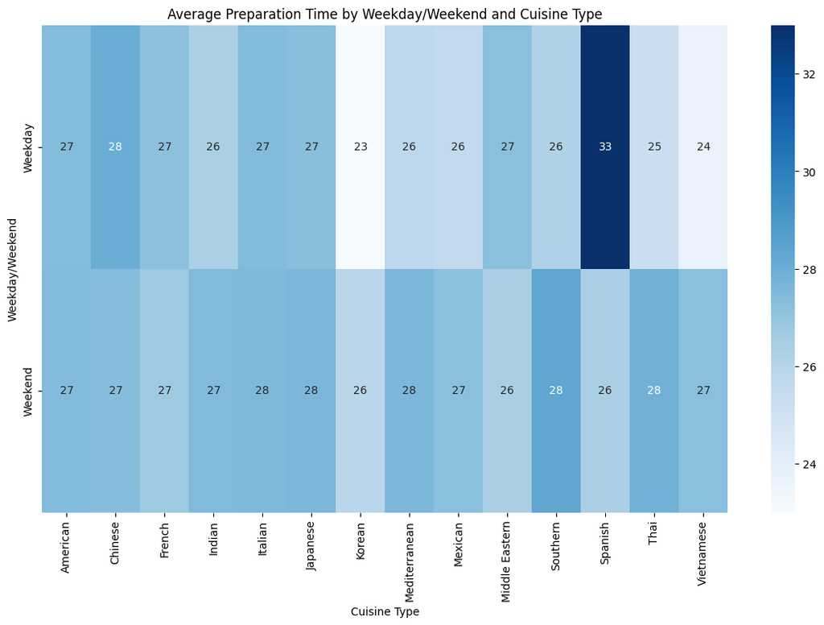

| cuisine_type day_of_the_week | American | Chinese | French | Indian | Italian | Japanese | Korean | Mediterranean | Mexican | Middle Eastern | Southern | Spanish | Thai | Vietnamese |
| --- | --- | --- | --- | --- | --- | --- | --- | --- | --- | --- | --- | --- | --- | --- |
| Weekday | 27.408284 | 28.076923 | 27.200000 | 26.333333 | 27.417582 | 27.281481 | 23.000000 | 25.785714 | 25.625000 | 27.235294 | 26.166667 | 33.000000 | 25.250000 | 23.666667 |
| Weekend | 27.453012 | 27.331288 | 26.769231 | 27.489796 | 27.512077 | 27.602985 | 25.909091 | 27.531250 | 27.226415 | 26.375000 | 28.363636 | 26.363636 | 27.866667 | 27.250000 |

```python
# Calculate total time (preparation time + delivery time)
data['total_time'] = data['food_preparation_time'] + data['delivery_time']

# Group by cuisine type and calculate average total time
avg_total_time_by_cuisine = data.groupby('cuisine_type')['total_time'].mean().reset_index()
avg_total_time_by_cuisine.columns = ['cuisine_type', 'average_total_time']

# Style the table using pandas Styler
styled_avg_total_time_by_cuisine = avg_total_time_by_cuisine.style.background_gradient(cmap='viridis').set_caption("Average Total Time by Cuisine Type")

# Display the styled table
styled_avg_total_time_by_cuisine

# Create a pivot table for average preparation time by Weekday/Weekend and cuisine type
pivot_table_preparation_time = data.pivot_table(values='food_preparation_time', index='day_of_the_week', columns='cuisine_type', aggfunc='mean')

# Visualize the pivot table as a heatmap
plt.figure(figsize=(14, 8))
sns.heatmap(pivot_table_preparation_time, annot=True, cmap='Blues')
plt.title('Average Preparation Time by Weekday/Weekend and Cuisine Type')
plt.xlabel('Cuisine Type')
plt.ylabel('Weekday/Weekend')
plt.show()

pivot_table_preparation_time
```

## **Observations**

**Cuisine Types with Longest Preparation Times on Weekdays**:

- Spanish: Average preparation time is approximately 33.00 minutes.
- Chinese: Average preparation time is approximately 28.08 minutes.
- Italian: Average preparation time is approximately 27.42 minutes.

**Cuisine Types with Shortest Preparation Times on Weekends**:

- Korean: Average preparation time is approximately 25.91 minutes.
- Middle Eastern: Average preparation time is approximately 26.38 minutes.
- Spanish: Average preparation time is approximately 26.36 minutes.

**Comparison Between Weekdays and Weekends**:

- The difference in preparation times between weekdays and weekends is more pronounced for certain cuisines like Spanish and Southern.
- Some cuisines have minimal differences in preparation times between weekdays and weekends, indicating consistent preparation times.

## Average Total Time by Day of the Week and Cuisine Type

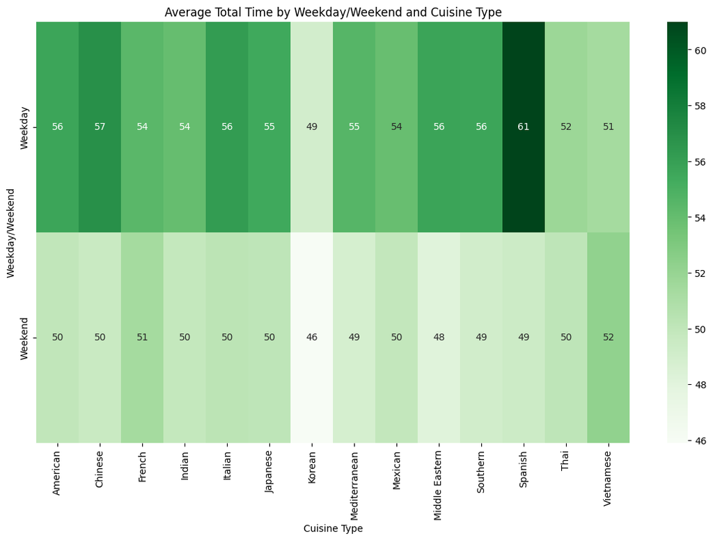

| cuisine_type day_of_the_week | American | Chinese | French | Indian | Italian | Japanese | Korean | Mediterranean | Mexican | Middle Eastern | Southern | Spanish | Thai | Vietnamese |
| --- | --- | --- | --- | --- | --- | --- | --- | --- | --- | --- | --- | --- | --- | --- |
| Weekday | 55.656805 | 56.903846 | 54.400000 | 53.958333 | 56.219780 | 55.414815 | 49.000000 | 54.571429 | 53.875000 | 55.705882 | 55.666667 | 61.000000 | 51.750000 | 51.333333 |
| Weekend | 49.995181 | 49.601227 | 51.384615 | 49.836735 | 50.217391 | 50.122388 | 45.909091 | 48.843750 | 49.867925 | 48.125000 | 49.090909 | 49.363636 | 50.133333 | 52.250000 |

```python
# Calculate total time (preparation time + delivery time)
data['total_time'] = data['food_preparation_time'] + data['delivery_time']

# Create a pivot table for average total time by Weekday/Weekend and cuisine type
pivot_table_total_time = data.pivot_table(values='total_time', index='day_of_the_week', columns='cuisine_type', aggfunc='mean')

# Visualize the pivot table as a heatmap
plt.figure(figsize=(14, 8))
sns.heatmap(pivot_table_total_time, annot=True, cmap='Greens')
plt.title('Average Total Time by Weekday/Weekend and Cuisine Type')
plt.xlabel('Cuisine Type')
plt.ylabel('Weekday/Weekend')
plt.show()

pivot_table_total_time
```

## **Observations**

**Weekday vs. Weekend Total Times:::

- Weekdays: Total times are generally higher across most cuisine types compared to weekends.
- Weekends: Total times are generally lower, indicating quicker overall preparation and delivery on weekends.

**Cuisine Types with Longest Total Times on Weekdays**:

- Spanish: Average total time is approximately 61.00 minutes.
- Chinese: Average total time is approximately 56.90 minutes.
- Italian: Average total time is approximately 56.22 minutes.
- Middle Eastern: Average total time is approximately 55.71 minutes.
- Southern: Average total time is approximately 55.67 minutes.

**Comparison Between Weekdays and Weekends**:

- The difference in total times between weekdays and weekends is more pronounced for certain cuisines like Spanish, Chinese, and Italian.
- Some cuisines have minimal differences in total times between weekdays and weekends, indicating consistent preparation and delivery times.

## Order Frequency by Preparation, Delivery and Total Time

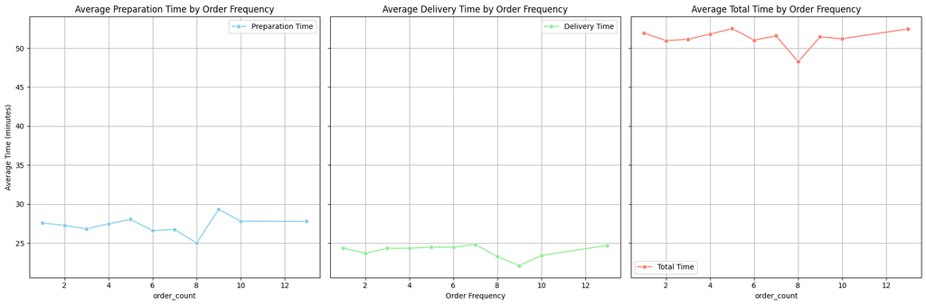

```python
# Calculate total time (preparation time + delivery time)
data['total_time'] = data['food_preparation_time'] + data['delivery_time']

# Calculate order frequency for each customer
order_frequency = data['customer_id'].value_counts().reset_index()
order_frequency.columns = ['customer_id', 'order_count']

# Merge the order frequency with the original dataset
merged_data = pd.merge(data, order_frequency, on='customer_id')

# Calculate the average preparation, delivery, and total time for different order frequencies
avg_times_by_frequency = merged_data.groupby('order_count').agg({
    'food_preparation_time': 'mean',
    'delivery_time': 'mean',
    'total_time': 'mean'
}).reset_index()
avg_times_by_frequency.columns = ['order_count', 'average_preparation_time', 'average_delivery_time', 'average_total_time']

# Plotting the average preparation, delivery, and total time by order frequency side by side
fig, ax = plt.subplots(1, 3, figsize=(18, 6), sharey=True)

# Preparation Time
sns.lineplot(ax=ax[0], x='order_count', y='average_preparation_time', data=avg_times_by_frequency, marker='o', color='skyblue', label='Preparation Time')
ax[0].set_title('Average Preparation Time by Order Frequency')
#ax[0].set_xlabel('Order Frequency')
ax[0].set_ylabel('Average Time (minutes)')
ax[0].grid(True)
ax[0].legend()

# Delivery Time
sns.lineplot(ax=ax[1], x='order_count', y='average_delivery_time', data=avg_times_by_frequency, marker='o', color='lightgreen', label='Delivery Time')
ax[1].set_title('Average Delivery Time by Order Frequency')
ax[1].set_xlabel('Order Frequency')
ax[1].grid(True)
ax[1].legend()

# Total Time
sns.lineplot(ax=ax[2], x='order_count', y='average_total_time', data=avg_times_by_frequency, marker='o', color='salmon', label='Total Time')
ax[2].set_title('Average Total Time by Order Frequency')
#ax[2].set_xlabel('Order Frequency')
ax[2].grid(True)
ax[2].legend()

plt.tight_layout()
plt.show()
```

## **Observations**

**Average Preparation Time**:

- 1 Order: Average preparation time is approximately 27.58 minutes.
- 2 Orders: Slightly decreases to approximately 27.25 minutes.
- 3 Orders: Decreases further to approximately 26.83 minutes.
- 4 Orders: Increases to approximately 27.47 minutes.
- 8 Orders: Significantly drops to approximately 25.00 minutes.
- 9 Orders: Peaks at approximately 29.33 minutes.

**Average Total Time**:

- 1 Order: Average total time is approximately 51.93 minutes.
- 2 Orders: Decreases slightly to approximately 50.96 minutes.
- 3 Orders: Slightly increases to approximately 51.14 minutes.
- 8 Orders: Drops significantly to approximately 48.25 minutes.
- 10 Orders: Is stable at approximately 51.20 minutes.
- 13 Orders: Increases to approximately 52.46 minutes.

**Insights**

- General Trend:
  - Preparation, delivery, and total times show some fluctuation with the number of orders placed by customers.
  - Customers with a higher frequency of orders tend to have slightly more efficient preparation times around 8 orders but this is not consistent.
- **Efficiency Peaks**:
  - A notable drop in preparation and total times occurs at 8 orders, suggesting possible improvements in efficiency for these frequent customers.
- **Inconsistencies**:
  - The preparation time increases again for customers with 9 orders, suggesting possible inconsistencies or operational challenges for this group. Consistent Delivery Times:
  - Delivery times remain relatively stable with minor fluctuations across different order frequencies.

## Order Frequency by Day of the Week

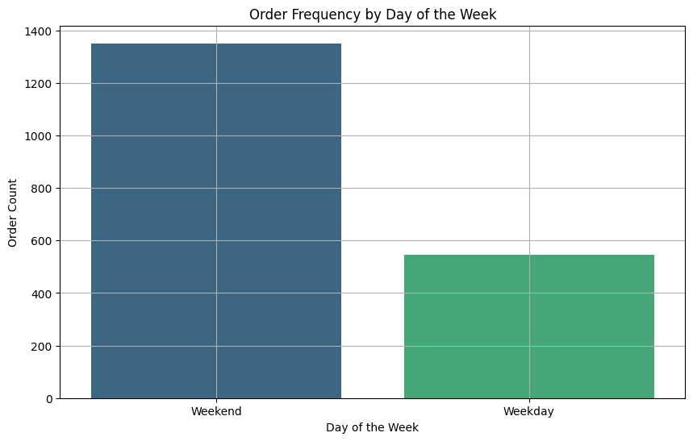

```python
# Calculate the order frequency by day of the week
order_frequency_by_day = data['day_of_the_week'].value_counts().reset_index()
order_frequency_by_day.columns = ['day_of_the_week', 'order_count']

# Style the table using pandas Styler
styled_order_frequency_by_day = order_frequency_by_day.style.background_gradient(cmap='viridis').set_caption("Order Frequency by Day of the Week")

# Display the styled table
styled_order_frequency_by_day

# Plotting the order frequency by day of the week
plt.figure(figsize=(10, 6))
sns.barplot(x='day_of_the_week', y='order_count', data=order_frequency_by_day, palette='viridis')
plt.title('Order Frequency by Day of the Week')
plt.xlabel('Day of the Week')
plt.ylabel('Order Count')
#plt.xticks(rotation=90)
plt.grid(True)
plt.show()
```

## **Observations**

- **Order Frequency on Weekdays vs. Weekends**:
  - Weekends: There is a significantly higher order frequency on weekends, with 1351 orders.
  - Weekdays: The order frequency on weekdays is lower, with 547 orders.
- **Higher Order Volumes on Weekends**:
  - The data clearly shows that customers place more orders on weekends compared to weekdays. This could be due to various factors such as more free time, social gatherings, and special occasions.
- **Lower Order Volumes on Weekdays**:
  - The lower order frequency on weekdays suggests that customers may be busier with work and other commitments, leading to fewer orders.

# **Outlier Analysis**

```
Number of outliers detected in cost_of_the_order: 0
Number of outliers detected in rating: 0
Number of outliers detected in food_preparation_time: 0
Number of outliers detected in delivery_time: 0
Number of outliers detected in total_wait_time: 0
```

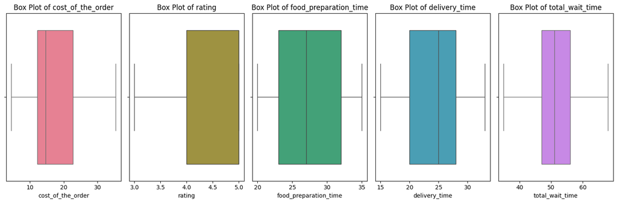

```
Summary of Outlier Counts:
cost_of_the_order: 0 outliers
rating: 0 outliers
food_preparation_time: 0 outliers
delivery_time: 0 outliers
total_wait_time: 0 outliers

Data after removing outliers: 1162 records remaining.
```

```python
# Convert 'rating' to numeric, replacing 'Not given' with NaN
data['rating'] = pd.to_numeric(data['rating'].replace('Not given', pd.NA), errors='coerce')

# Calculate the total wait time
data['total_wait_time'] = data['food_preparation_time'] + data['delivery_time']

# Identify numeric columns
numeric_columns = data.select_dtypes(include=[np.number]).columns
numeric_columns = numeric_columns.drop('customer_id')   # Exclude 'customer_id' from the analysis
numeric_columns = numeric_columns.drop('order_id')      # Exclude 'order_id' from the analysis

# Determine the number of rows and columns for the subplot grid
num_cols = 5
num_rows = math.ceil(len(numeric_columns) / num_cols)

# Set up the subplots
fig, axes = plt.subplots(nrows=num_rows, ncols=num_cols, figsize=(15, num_rows * 5))
colors = sns.color_palette("husl", len(numeric_columns))  # Generate a color palette

# Flatten the axes array for easy iteration
axes = axes.flatten()

# Step 2 & 3: Visualize Outliers and Identify Outliers using IQR method for each numeric column
outlier_counts = {}

for i, col in enumerate(numeric_columns):
    sns.boxplot(x=data[col], ax=axes[i], color=colors[i])
    axes[i].set_title(f'Box Plot of {col}')
    axes[i].set_xlabel(col)

    # Calculate IQR
    Q1 = data[col].quantile(0.25)
    Q3 = data[col].quantile(0.75)
    IQR = Q3 - Q1

    # Define outliers
    lower_bound = Q1 - 1.5 * IQR
    upper_bound = Q3 + 1.5 * IQR

    # Identify outliers
    outliers = data[(data[col] < lower_bound) | (data[col] > upper_bound)]
    outlier_counts[col] = len(outliers)

    # Print outliers count
    print(f"Number of outliers detected in {col}: {len(outliers)}")

# Remove any empty subplots
for j in range(i + 1, len(axes)):
    fig.delaxes(axes[j])

# Adjust layout
plt.tight_layout()
plt.show()

# Print summary of outliers in each column
print("\nSummary of Outlier Counts:")
for col, count in outlier_counts.items():
    print(f"{col}: {count} outliers")

# Optional: Remove outliers (across all numeric columns)
for col in numeric_columns:
    Q1 = data[col].quantile(0.25)
    Q3 = data[col].quantile(0.75)
    IQR = Q3 - Q1
    lower_bound = Q1 - 1.5 * IQR
    upper_bound = Q3 + 1.5 * IQR

    # Remove outliers
    data = data[(data[col] >= lower_bound) & (data[col] <= upper_bound)]

# Summary of the cleaned data
print(f"\nData after removing outliers: {len(data)} records remaining.")
```

### **Question 13:** The company wants to provide a promotional offer in the advertisement of the restaurants. The condition to get the offer is that the restaurants must have a rating count of more than 50 and the average rating should be greater than 4. Find the restaurants fulfilling the criteria to get the promotional offer

```python
# Filter out rows where rating is 'Not given'
filtered_data = data[data['rating'] != 'Not given']
filtered_data['rating'] = filtered_data['rating'].astype(float)

# Calculate the rating count and average rating for each restaurant
restaurant_ratings = filtered_data.groupby('restaurant_name')['rating'].agg(['count', 'mean']).reset_index()
restaurant_ratings.columns = ['restaurant_name', 'rating_count', 'average_rating']

# Filter the restaurants that meet the criteria: rating count > 50 and average rating > 4
eligible_restaurants = restaurant_ratings[(restaurant_ratings['rating_count'] > 50) & (restaurant_ratings['average_rating'] > 4)]

# Style the table using pandas Styler with all column headers centered and data left-justified, except for rating_count data which is centered
styled_eligible_restaurants = (eligible_restaurants.style
                               .set_properties(subset=['restaurant_name'], **{'text-align': 'left'})
                               .set_properties(subset=['rating_count'], **{'text-align': 'center'})
                               .set_table_styles([{
                                   'selector': 'th',
                                   'props': [('text-align', 'center')]
                               }])
                               .set_caption("Restaurants Eligible for Promotional Offer"))

# Display the styled table
styled_eligible_restaurants
```

Restaurants Eligible for Promotional Offer

|  | restaurant_name | rating_count | average_rating |
| --- | --- | --- | --- |
| 20 | Blue Ribbon Fried Chicken | 64 | 4.328125 |
| 21 | Blue Ribbon Sushi | 73 | 4.219178 |
| 136 | Shake Shack | 133 | 4.278195 |
| 153 | The Meatball Shop | 84 | 4.511905 |

### **Question 14:** The company charges the restaurant 25% on the orders having cost greater than 20 dollars and 15% on the orders having cost greater than 5 dollars. Find the net revenue generated by the company across all orders

```python
# Define the function to calculate the commission based on order cost
def calculate_commission(cost):
    if cost > 20:
        return cost * 0.25
    elif cost > 5:
        return cost * 0.15
    else:
        return 0

# Apply the function to calculate the commission for each order
data['commission'] = data['cost_of_the_order'].apply(calculate_commission)

# Calculate the total revenue generated by the company
total_revenue = data['commission'].sum()

# Print the total revenue generated by the company with a formatted string, rounded to 2 decimal places
print(f"The total net revenue generated by the company across all orders, based on the given commission structure, is ${total_revenue:.2f}")
```

```
The total net revenue generated by the company across all orders, based on the given commission structure, is $6166.30
```

#### Observations:

**Revenue from Low-Cost Orders**:

- Orders with a cost less than or equal to $5 do not contribute to the revenue as they fall outside the commission structure.
- The company should focus on increasing the average order value to maximize revenue.
- Impact of Commission Structure:
  - The tiered commission structure ensures that higher-value orders contribute more to the revenue.
  - This structure incentivizes promoting higher-value items and potentially increasing the average order value.

**Recommendations**

- Promote Higher-Value Items:
  - Encourage customers to place higher-value orders through promotions or bundling items, which would increase the number of orders qualifying for the 25% commission rate.
- Increase Average Order Value:
  - Implement strategies to increase the average order value, such as offering discounts on add-ons or creating special offers for orders above a certain amount.
- Monitor and Adjust Commission Structure:
  - Regularly review the commission structure to ensure it aligns with the company's revenue goals and market conditions.
  - Consider adjustments based on order patterns and customer feedback to optimize revenue.
- Customer Engagement:
  - Engage customers with targeted marketing campaigns highlighting high-value items and special promotions to drive higher-order volumes.

### **Question 15:** The company wants to analyze the total time required to deliver the food. What percentage of orders take more than 60 minutes to get delivered from the time the order is placed? (The food has to be prepared and then delivered)

```python
# Write the code here# Calculate total time (preparation time + delivery time)
data['total_time'] = data['food_preparation_time'] + data['delivery_time']

# Calculate the percentage of orders that take more than 60 minutes to get delivered
total_orders = len(data)
orders_over_60_minutes = len(data[data['total_time'] > 60])
percentage_over_60_minutes = (orders_over_60_minutes / total_orders) * 100

# Print the percentage of orders that take more than 60 minutes
print(f"The percentage of orders that take more than 60 minutes to get delivered is {percentage_over_60_minutes:.2f}%")
```

```
The percentage of orders that take more than 60 minutes to get delivered is 10.54%
```

#### Observations:

**Percentage of Orders Over 60 Minutes**:

- The analysis shows that 10.54% of the orders take more than 60 minutes to get delivered from the time the order is placed.

**Implications of Long Delivery Times**:

- Orders taking more than 60 minutes could indicate inefficiencies in the preparation or delivery process.
- Long delivery times may affect customer satisfaction and lead to negative reviews or reduced repeat business.

### **Question 16:** The company wants to analyze the delivery time of the orders on weekdays and weekends. How does the mean delivery time vary during weekdays and weekends?

```python
# Write the code here# Calculate the mean delivery time for weekdays and weekends
mean_delivery_time_by_day = data.groupby('day_of_the_week')['delivery_time'].mean().reset_index()

# Separate weekdays and weekends
weekdays = mean_delivery_time_by_day[mean_delivery_time_by_day['day_of_the_week'] == 'Weekday']['delivery_time'].values[0]
weekends = mean_delivery_time_by_day[mean_delivery_time_by_day['day_of_the_week'] == 'Weekend']['delivery_time'].values[0]

# Print the mean delivery times
print(f"The mean delivery time on weekdays is {weekdays:.2f} minutes.")
print(f"The mean delivery time on weekends is {weekends:.2f} minutes.")
```

```
The mean delivery time on weekdays is 28.34 minutes.
The mean delivery time on weekends is 22.47 minutes.
```

#### Observations:

**Mean Delivery Time on Weekdays**:

- The mean delivery time on weekdays is approximately 28.34 minutes. Mean Delivery Time on Weekends:
- The mean delivery time on weekends is approximately 22.47 minutes.

### Conclusion and Recommendations

Delivery times on weekdays is appreciably longer than on weekends despite generally higher order frequency on weekends

**Improve Weekday Efficiency**:

- Investigate the factors contributing to longer delivery times on weekdays. Consider optimizing delivery routes, increasing staffing levels, or streamlining operations to reduce delivery times.

**Maintain Weekend Efficiency**:

- Continue leveraging the efficiencies observed on weekends. Analyze the processes that work well during weekends and see if they can be applied to weekdays.

### **Question 17:** What are your conclusions from the analysis? What recommendations would you like to share to help improve the business? (You can use cuisine type and feedback ratings to drive your business recommendations)

### Conclusions:

**Long Delivery Times**:

- 10.54% of orders take more than 60 minutes to get delivered, indicating potential inefficiencies in the preparation or delivery process.

**Delivery Times on Weekdays vs. Weekends**:

- Mean delivery time on weekdays is approximately 28.34 minutes. Mean delivery time on weekends is shorter, at approximately 22.47 minutes.

**Highly Rated Restaurants**:

- Certain restaurants like Shake Shack and The Meatball Shop have high average ratings and a substantial number of ratings, making them prime candidates for promotional offers.

**Order Frequency by Day of the Week**:

- Order frequency is significantly higher on weekends compared to weekdays, suggesting a shift in customer behavior and demand.

### Recommendations:

**Optimize Delivery Efficiency on Weekdays**:

- Route Optimization: Use advanced routing algorithms to find the most efficient delivery routes during peak weekday hours.
- Staffing Adjustments: Increase staffing levels during peak times on weekdays to handle higher traffic and ensure timely deliveries.
- Preparation Processes: Streamline kitchen operations to reduce preparation times, possibly by pre-prepping ingredients for popular dishes.

**Leverage High Customer Ratings**:

- Promotional Campaigns: Highlight highly rated restaurants like Shake Shack and The Meatball Shop in promotional campaigns to attract more customers.
- Customer Feedback: Regularly solicit and analyze customer feedback to identify strengths and areas for improvement. Use this feedback to maintain high service standards and improve underperforming areas.

**Focus on Weekend Efficiency**:

- Best Practices: Analyze the factors contributing to shorter delivery times on weekends and apply these best practices to weekdays.
- Weekend Promotions: Continue leveraging the high order volumes on weekends with special offers and promotions to maximize revenue.

**Enhance Customer Experience**:

- Transparent Communication: Clearly communicate estimated delivery times to customers and provide real-time updates on order status.
- Compensation for Delays: Offer compensation or discounts for orders that are significantly delayed to maintain customer trust and satisfaction.

**Improve Cuisine-Specific Offerings**:

- Menu Optimization: Analyze the preparation and delivery times for different cuisine types. Focus on optimizing the processes for cuisines with longer average times (e.g., Spanish, Chinese).
- Targeted Promotions: Offer targeted promotions for cuisines that have high ratings but longer delivery times to balance the demand and improve overall delivery efficiency.

**Incentivize Higher-Value Orders**:

- Bundled Offers: Create bundled meal deals that encourage customers to place higher-value orders, which contribute more to the company’s revenue.
- Loyalty Programs: Implement loyalty programs that reward customers for placing higher-value orders and frequent orders, driving repeat business.

```python
# Convert notebook to html

import os
os.getcwd()
!jupyter nbconvert --to html "/content/drive/MyDrive/MIT - Data Sciences/Colab Notebooks/Week Two - Statistics for Data Science/Project Assessment - FoodHub/FDS_Project_LearnerNotebook_FullCode.ipynb"
```

```
[NbConvertApp] Converting notebook /content/drive/MyDrive/MIT - Data Sciences/Colab Notebooks/Week Two - Statistics for Data Science/Project Assessment - FoodHub/FDS_Project_LearnerNotebook_FullCode.ipynb to html
[NbConvertApp] Writing 3452465 bytes to /content/drive/MyDrive/MIT - Data Sciences/Colab Notebooks/Week Two - Statistics for Data Science/Project Assessment - FoodHub/FDS_Project_LearnerNotebook_FullCode.html
```